# RQ3: Will a district’s building consents rise or fall next year?

Building consents (Stats NZ, Aug 2026) — logistic regression, discriminant analysis and tree-based classifiers

Andrew Boulton — while True: learn(), Group 8, STAT462

This document answers research question 3 of our project: *can a district’s recent consent record tell us whether its new-dwelling consents will rise or fall next year?* It turns the district-by-quarter table into one row per district and year, defines the class (rise or fall), builds features that are known by the end of each year, and looks at the data before fitting anything. It then fits the classifiers in the order the course teaches them: logistic regression (Module 3), linear and quadratic discriminant analysis (Module 4), and a classification tree, bagging, a random forest and boosting (Module 6). Every model is judged on the same time-ordered test set — the outcomes of 2020 to 2025 — by its confusion matrix, accuracy and AUC, and against four rules of thumb that need no model at all.

# 1 Set up

## 1.1 Data

The starting point is the same district-by-quarter table as RQ1 and RQ2, built by Niwesh’s Step 1 notebook from the Stats NZ *Building consents by territorial authority (Monthly)* file. We read the full version, with every quarter kept, because this question is about counts of dwellings and has no use for RQ1’s minimum of five houses.

```r
quarters <- read_csv(file.path(data_root, "rq1_district_quarter_full.csv"),
                     show_col_types = FALSE)

cat("Rows:", nrow(quarters), " Columns:", ncol(quarters),
    " Districts:", n_distinct(quarters$ta),
    " Quarters:", min(quarters$yq), "to", max(quarters$yq), "\n")
```

```
## Rows: 9715  Columns: 43  Districts: 67  Quarters: 1990Q2 to 2026Q2
```

## 1.2 From quarters to district-years

The question is about calendar years, so quarters are added up to years. A year is only used if all four of its quarters are in the data: 1990 starts in its second quarter and 2026 stops after its second, so both are dropped. Dollar figures are put into June-2026 dollars quarter by quarter before they are added, using the `real_factor` column from Step 1.

```r
years <- quarters %>%
  mutate(alt_real    = resid_alt_val * real_factor,
         new_real    = resid_new_val * real_factor,
         nonres_real = nonres_new_val * real_factor,
         houses_real = houses_val * real_factor) %>%
  group_by(ta, region, year) %>%
  summarise(n_quarters  = n(),
            dwellings   = sum(dwell_n),               # new dwelling units of every type
            houses      = sum(houses_n),              # of which stand-alone houses
            first_half  = sum(dwell_n[quarter <= 2]), # dwellings consented January-June
            second_half = sum(dwell_n[quarter >= 3]), # dwellings consented July-December
            alt_real    = sum(alt_real),
            new_real    = sum(new_real),
            nonres_real = sum(nonres_real),
            houses_real = sum(houses_real),
            houses_m2   = sum(houses_m2),
            .groups = "drop") %>%
  # complete calendar years only
  dplyr::filter(n_quarters == 4) %>%
  arrange(ta, year)

cat("District-years:", nrow(years), " Districts:", n_distinct(years$ta),
    " Years:", min(years$year), "to", max(years$year), "\n")
```

```
## District-years: 2345  Districts: 67  Years: 1991 to 2025
```

2,345 district-years: 67 districts by 35 complete years, 1991 to 2025.

## 1.3 The class

A district-year is **rising** if the district consented more new dwellings in the following calendar year than in this one. The class of year $t$ therefore needs year $t + 1$, so the last year that can be classified is 2024 (its “next year” is 2025).

```r
years <- years %>%
  group_by(ta) %>%
  mutate(dwellings_next = lead(dwellings),     # the same district, one year on
         dwellings_last = lag(dwellings)) %>%  # the same district, one year back
  ungroup() %>%
  mutate(rising = as.integer(dwellings_next > dwellings))

obs <- years %>% dplyr::filter(!is.na(dwellings_next))

cat("District-years with a class:", nrow(obs), " (", min(obs$year), "to", max(obs$year), ")\n")
```

```
## District-years with a class: 2278  ( 1991 to 2024 )
```

```r
cat("Share rising:", round(mean(obs$rising), 4), "\n")
```

```
## Share rising: 0.5123
```

```r
cat("Ties (next year exactly equal to this year):", sum(obs$dwellings_next == obs$dwellings), "\n")
```

```
## Ties (next year exactly equal to this year): 52
```

2,278 district-years have a class, 67 districts by 34 years, and 51.2% of them are rising. The two classes are close to balanced, so accuracy is a fair headline measure and a model that learned nothing would score about half.

**Ties.** In 52 district-years the next year’s count equals this year’s exactly. They are counted as *not rising*, which is the definition we pitched (“rising” means strictly more). We call the two classes Rise and Fall for short; Fall includes those 52.

## 1.4 Features known at the end of the year

A forecast made at the end of year $t$ can only use what is known then. Each feature below is built from year $t$ and earlier, never from year $t + 1$.

| Feature | Question it answers | How it is built |
| --- | --- | --- |
| `g1` | Did consents grow this year? | log of this year’s dwellings ÷ last year’s |
| `dev3` | Is this year high or low for this district? | log of this year’s dwellings ÷ the average of the three years before |
| `h2_h1` | Was the year speeding up or slowing down? | log of July–December dwellings ÷ January–June |
| `log_dwell` | How big is the district’s market? | log of this year’s dwellings |
| `multi_share` | What is being built? | share of this year’s dwellings that are not stand-alone houses |
| `alt_share` | How much work is on existing homes? | alterations $ ÷ (alterations $ + new residential $) |
| `nonres_share` | How much building is not housing? | new non-residential $ ÷ (non-residential $ + new residential $) |
| `cv5` | How erratic is the district? | standard deviation ÷ mean of its last five years of dwellings |
| `nat_g1` | Did the whole country grow this year? | log of this year’s national dwellings ÷ last year’s |

Counts have 1 added before a log or a ratio is taken, so that a year with no consents (the Chatham Islands has several) does not produce an infinite value.

```r
# standard deviation and mean of the five values ending at each position of x
sd_last5   <- function(x) sapply(seq_along(x), function(i) if (i < 5) NA else sd(x[(i - 4):i]))
mean_last5 <- function(x) sapply(seq_along(x), function(i) if (i < 5) NA else mean(x[(i - 4):i]))

# one row per year for the country as a whole (the 67 districts added up)
national <- years %>%
  group_by(year) %>%
  summarise(nz_dwellings = sum(dwellings),
            nz_cost_m2   = sum(houses_real) / sum(houses_m2)) %>%
  mutate(nat_g1 = log(nz_dwellings / lag(nz_dwellings)))

df_all <- years %>%
  group_by(ta) %>%
  mutate(avg3  = (lag(dwellings, 1) + lag(dwellings, 2) + lag(dwellings, 3)) / 3,
         sd5   = sd_last5(dwellings),
         mean5 = mean_last5(dwellings)) %>%
  ungroup() %>%
  left_join(national, by = "year") %>%
  mutate(g1           = log((dwellings + 1) / (dwellings_last + 1)),
         dev3         = log((dwellings + 1) / (avg3 + 1)),
         h2_h1        = log((second_half + 1) / (first_half + 1)),
         log_dwell    = log(dwellings + 1),
         multi_share  = ifelse(dwellings > 0, 1 - houses / dwellings, 0),
         alt_share    = alt_real / (alt_real + new_real),
         nonres_share = nonres_real / (nonres_real + new_real),
         cv5          = sd5 / (mean5 + 1),
         # used in two sensitivity checks only (section 6), not as headline features
         rel_cost     = ifelse(houses_m2 > 0, log((houses_real / houses_m2) / nz_cost_m2), NA),
         change       = log((dwellings_next + 1) / (dwellings + 1)),
         # the class as a factor, for the models that want one
         direction    = factor(ifelse(rising == 1, "Rise", "Fall"), levels = c("Fall", "Rise")),
         # short names for tables: "Selwyn District" -> "Selwyn"
         district     = str_remove(ta, " District$| City$| Territory$"))

features <- c("g1", "dev3", "h2_h1", "log_dwell", "multi_share",
              "alt_share", "nonres_share", "cv5", "nat_g1")
```

The modelling table keeps the district-years that have a class and every feature. `cv5` needs five years of history, so the first usable year is 1995.

```r
df <- df_all %>%
  dplyr::filter(!is.na(dwellings_next)) %>%
  drop_na(all_of(features)) %>%
  dplyr::select(district, ta, region, year, dwellings, dwellings_next, change,
                rising, direction, all_of(features), rel_cost)

cat("Rows:", nrow(df), " Years:", min(df$year), "to", max(df$year),
    " Districts:", n_distinct(df$ta), "\n")
```

```
## Rows: 2009  Years: 1995 to 2024  Districts: 67
```

```r
# rows from 1995 onward that were lost to a missing feature, and which feature
df_all %>%
  dplyr::filter(!is.na(dwellings_next), year >= 1995) %>%
  dplyr::filter(if_any(all_of(features), is.na)) %>%
  dplyr::select(district, year, dwellings, alt_share, nonres_share) %>%
  knitr::kable(caption = "District-years from 1995 dropped for a missing feature")
```

District-years from 1995 dropped for a missing feature

| district | year | dwellings | alt_share | nonres_share |
| --- | --- | --- | --- | --- |
| Chatham Islands | 1998 | 0 | NaN | NaN |

2,009 rows: 67 districts by 30 years, less one. The Chatham Islands had no residential consents of any kind in 1998, so its two dollar shares cannot be computed for that year.

**`nat_g1` is a different kind of feature.** It has one value per year, the same for every district, so in the training data it takes only 24 distinct values. It is legitimate — the national total for year $t$ is known at the end of year $t$ — and it is the only feature that carries the national cycle. Section 6 shows the results without it.

**What was left out.** Cost per m² was on the pitch slide’s list of candidate features; section 6 adds it and shows it makes no difference. `region` is offered to the tree-based models only, as in RQ1, because logistic regression and discriminant analysis would need 16 dummy columns for it.

## 1.5 Train and test sets

The split is by time, as in RQ1, and at the same place: a model may learn from every outcome up to 2019 and is tested on the outcomes of 2020 to 2025. Because the class of year $t$ is the outcome of year $t + 1$, that means training on feature years up to 2018 and testing on feature years 2019 to 2024.

```r
df_train <- df %>% dplyr::filter(year <= 2018)
df_test  <- df %>% dplyr::filter(year >= 2019)

cat("Training set size:", nrow(df_train), " (feature years", min(df_train$year), "to", max(df_train$year),
    ") share rising:", round(mean(df_train$rising), 3), "\n")
```

```
## Training set size: 1607  (feature years 1995 to 2018 ) share rising: 0.533
```

```r
cat("Test set size:    ", nrow(df_test),  " (feature years", min(df_test$year),  "to", max(df_test$year),
    ") share rising:", round(mean(df_test$rising), 3), "\n")
```

```
## Test set size:     402  (feature years 2019 to 2024 ) share rising: 0.45
```

1,607 training rows and 402 test rows. Both sets are close to balanced, but they lean in opposite directions: 53.3% of the training rows are rises and 45.0% of the test rows. A model that simply learned “rises are a little more common” would be wrong more often than right on the test years.

# 2 First impression

## 2.1 The national cycle

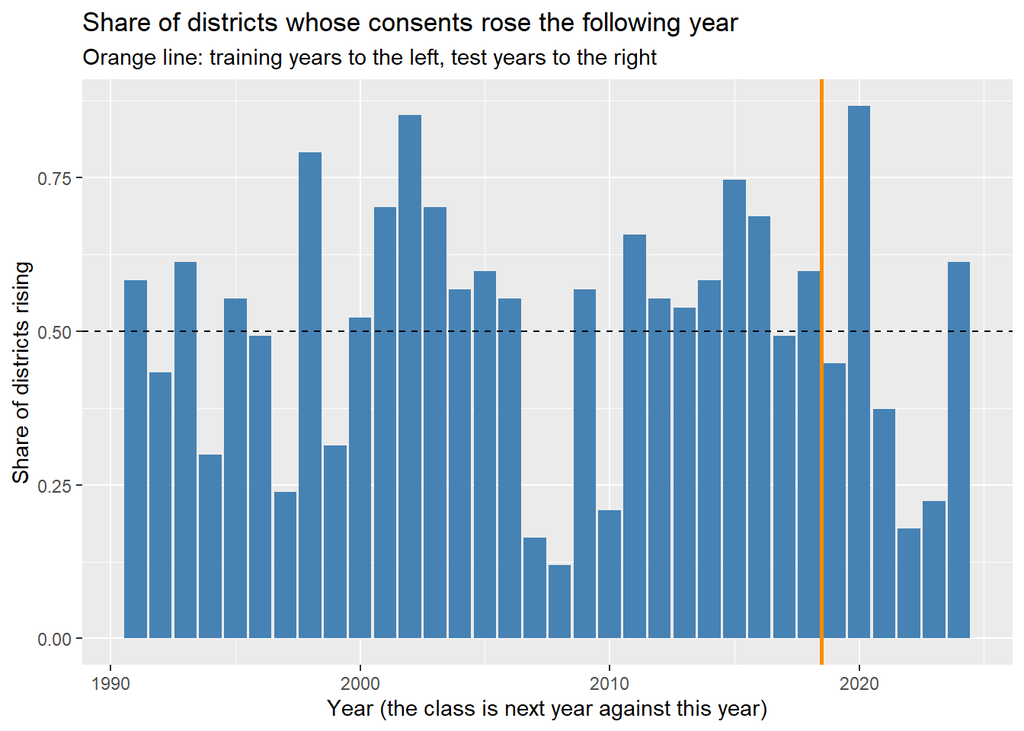

```r
cycle <- obs %>%
  group_by(year) %>%
  summarise(share_rising = mean(rising))

ggplot(cycle, aes(x = year, y = share_rising)) +
  geom_col(fill = "steelblue") +
  geom_hline(yintercept = 0.5, linetype = "dashed") +
  geom_vline(xintercept = 2018.5, colour = "darkorange", linewidth = 1) +
  labs(title = "Share of districts whose consents rose the following year",
       subtitle = "Orange line: training years to the left, test years to the right",
       x = "Year (the class is next year against this year)", y = "Share of districts rising")
```

```r
cycle %>%
  dplyr::filter(year >= 2019) %>%
  mutate(share_rising = round(share_rising, 2)) %>%
  knitr::kable(caption = "Test years: share of districts rising the following year")
```

Test years: share of districts rising the following year

| year | share_rising |
| --- | --- |
| 2019 | 0.45 |
| 2020 | 0.87 |
| 2021 | 0.37 |
| 2022 | 0.18 |
| 2023 | 0.22 |
| 2024 | 0.61 |

Districts move together. Only 12% of districts consented more dwellings in 2009 than in 2008, as the financial crisis took hold; 87% consented more in 2021 than in 2020. The six test years hold both extremes of the latest cycle: almost every district rose after 2020, and about four in five fell after 2022 and again after 2023.

How much of the class is that shared movement? If we somehow knew, for each year, which way most districts were about to go, and predicted that direction for every district:

```r
# share of district-years that moved with the majority of districts that year
majority <- obs %>%
  group_by(year) %>%
  mutate(with_majority = rising == as.integer(mean(rising) > 0.5)) %>%
  ungroup()

cat("All years 1991-2024:", round(mean(majority$with_majority), 3), "\n")
```

```
## All years 1991-2024: 0.66
```

```r
cat("Test years 2019-2024:", round(mean(majority$with_majority[majority$year >= 2019]), 3), "\n")
```

```
## Test years 2019-2024: 0.709
```

Two-thirds of all district-years (66%), and 71% in the test years, simply went the way most of the country went. That number is not available to any model — it uses next year’s outcome — but it is the right yardstick: the national direction is the largest single piece of the answer, and none of the district-level features can see it coming.

## 2.2 The features against the class

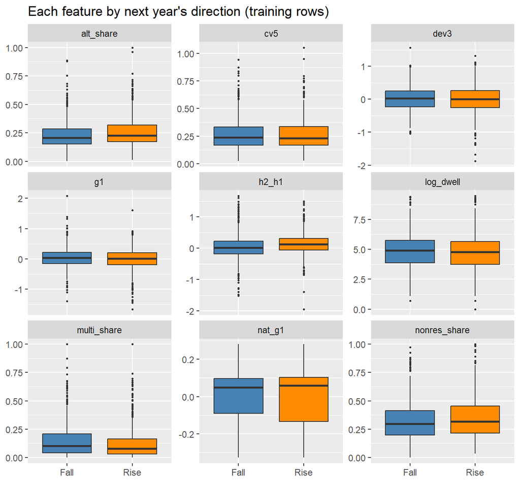

```r
df_train %>%
  dplyr::select(direction, all_of(features)) %>%
  pivot_longer(-direction, names_to = "feature", values_to = "value") %>%
  ggplot(aes(x = direction, y = value, fill = direction)) +
  geom_boxplot(outlier.size = 0.5) +
  facet_wrap(~ feature, scales = "free_y", ncol = 3) +
  scale_fill_manual(values = c("Fall" = "steelblue", "Rise" = "darkorange")) +
  labs(title = "Each feature by next year's direction (training rows)",
       x = NULL, y = NULL) +
  theme(legend.position = "none")
```

```r
# how far apart the two classes sit on each feature, in pooled standard deviations
df_train %>%
  dplyr::select(direction, all_of(features)) %>%
  pivot_longer(-direction, names_to = "feature", values_to = "value") %>%
  group_by(feature) %>%
  summarise(mean_fall = mean(value[direction == "Fall"]),
            mean_rise = mean(value[direction == "Rise"]),
            gap_in_sd = (mean_rise - mean_fall) / sd(value)) %>%
  arrange(desc(abs(gap_in_sd))) %>%
  mutate(across(where(is.numeric), ~ round(.x, 3))) %>%
  knitr::kable(caption = "Class means on each feature, and the gap between them in standard deviations")
```

Class means on each feature, and the gap between them in standard deviations

| feature | mean_fall | mean_rise | gap_in_sd |
| --- | --- | --- | --- |
| h2_h1 | 0.040 | 0.129 | 0.242 |
| alt_share | 0.229 | 0.258 | 0.222 |
| multi_share | 0.145 | 0.118 | -0.198 |
| g1 | 0.044 | -0.013 | -0.165 |
| nonres_share | 0.324 | 0.349 | 0.147 |
| nat_g1 | 0.005 | 0.023 | 0.110 |
| dev3 | 0.022 | -0.015 | -0.100 |
| log_dwell | 4.823 | 4.695 | -0.089 |
| cv5 | 0.267 | 0.263 | -0.030 |

The boxes overlap almost completely on every feature. That is the picture of a hard classification problem: no single feature separates the classes. The largest gap between the class means is a quarter of a standard deviation, on `h2_h1` — districts whose year finished stronger than it started are a little more likely to rise — followed by `alt_share` (0.22) and `multi_share` (−0.20). The two features that compare this year with the district’s own past, `g1` and `dev3`, have negative gaps: a district that is up on last year, or high against its three-year average, is slightly more likely to fall back. That is mean reversion, and it is faint (−0.17 and −0.10 standard deviations).

## 2.3 Rules of thumb

Before any model, four rules that a person could apply with a pencil. They set the bar: a model that cannot beat them has learned nothing a rule of thumb did not already know.

```r
# accuracy, sensitivity, specificity and precision from predicted and actual classes (1 = rise)
class_metrics <- function(pred_class, actual) {
  TP <- sum(pred_class == 1 & actual == 1)
  TN <- sum(pred_class == 0 & actual == 0)
  FP <- sum(pred_class == 1 & actual == 0)
  FN <- sum(pred_class == 0 & actual == 1)
  c(accuracy    = (TP + TN) / (TP + TN + FP + FN),
    sensitivity = TP / (TP + FN),                       # share of actual rises that were predicted
    specificity = TN / (TN + FP),                       # share of actual falls that were predicted
    precision   = ifelse(TP + FP > 0, TP / (TP + FP), NA))  # share of predicted rises that were right
}

# area under the ROC curve; direction is fixed so a model worse than chance is not flipped
auc_of <- function(prob, actual) {
  as.numeric(auc(roc(actual, prob, levels = c(0, 1), direction = "<", quiet = TRUE)))
}

# one table of test results that every section adds to
results <- tibble(model = character(), family = character(), accuracy = numeric(),
                  sensitivity = numeric(), specificity = numeric(),
                  precision = numeric(), AUC = numeric())

add_result <- function(results, model, family, pred_class, prob = NULL) {
  m <- class_metrics(pred_class, df_test$rising)
  bind_rows(results,
            tibble(model = model, family = family,
                   accuracy = m[["accuracy"]], sensitivity = m[["sensitivity"]],
                   specificity = m[["specificity"]], precision = m[["precision"]],
                   AUC = if (is.null(prob)) NA else auc_of(prob, df_test$rising)))
}

# the four rules, applied to the test rows
rule_majority  <- rep(as.integer(mean(df_train$rising) > 0.5), nrow(df_test))  # the more common class in training
rule_same      <- as.integer(df_test$g1 > 0)      # rose this year, so will rise again
rule_opposite  <- as.integer(df_test$g1 <= 0)     # rose this year, so will fall back
rule_reversion <- as.integer(df_test$dev3 < 0)    # below its own three-year average, so will rise

results <- results %>%
  add_result("Always the more common class in training", "rule of thumb", rule_majority) %>%
  add_result("Same direction as this year",              "rule of thumb", rule_same) %>%
  add_result("Opposite direction to this year",          "rule of thumb", rule_opposite) %>%
  add_result("Below own 3-year average: rise",           "rule of thumb", rule_reversion)

results %>%
  mutate(across(where(is.numeric), ~ round(.x, 3))) %>%
  knitr::kable(caption = "Rules of thumb on the test set")
```

Rules of thumb on the test set

| model | family | accuracy | sensitivity | specificity | precision | AUC |
| --- | --- | --- | --- | --- | --- | --- |
| Always the more common class in training | rule of thumb | 0.450 | 1.000 | 0.000 | 0.450 | NA |
| Same direction as this year | rule of thumb | 0.460 | 0.398 | 0.511 | 0.400 | NA |
| Opposite direction to this year | rule of thumb | 0.540 | 0.602 | 0.489 | 0.491 | NA |
| Below own 3-year average: rise | rule of thumb | 0.585 | 0.575 | 0.593 | 0.536 | NA |

Persistence fails: “same direction as this year” is right 46% of the time, worse than tossing a coin, and “always rise”, the more common class in training, is right 45% of the time. The mirror image of persistence does better (54%), and the best of the four is the mean-reversion rule — a district below its own three-year average will rise, one above it will fall — at 58.5%. That is the bar on these test years. Section 6.4 asks whether the rule does as well in other years.

# 3 Logistic regression

Logistic regression models the probability of the Rise class directly. With one feature $x$:

$$p(x) = \frac{e^{b_0 + b_1 x}}{1 + e^{b_0
+ b_1 x}}$$

and a district-year is classified as Rise when $p(x)$ is above a threshold, 0.5 unless there is a reason to choose otherwise.

## 3.1 Simple logistic regression

We start with the single feature behind the best rule of thumb, `dev3`.

```r
logreg.simple <- glm(rising ~ dev3, data = df_train, family = binomial)
summary(logreg.simple)
```

```
##
## Call:
## glm(formula = rising ~ dev3, family = binomial, data = df_train)
##
## Coefficients:
##             Estimate Std. Error z value Pr(>|z|)
## (Intercept)  0.13184    0.05006   2.633  0.00845 **
## dev3        -0.27023    0.13538  -1.996  0.04592 *
## ---
## Signif. codes:  0 '***' 0.001 '**' 0.01 '*' 0.05 '.' 0.1 ' ' 1
##
## (Dispersion parameter for binomial family taken to be 1)
##
##     Null deviance: 2220.9  on 1606  degrees of freedom
## Residual deviance: 2216.9  on 1605  degrees of freedom
## AIC: 2220.9
##
## Number of Fisher Scoring iterations: 3
```

The slope is negative (−0.27, $p = 0.046$): the further a district is above its recent average, the less likely it is to rise again. It is also weak — the residual deviance, 2216.9, is barely below the null deviance of 2220.9.

The probability for each test row can be computed from the two coefficients by the formula above, or with `predict()`. Doing it both ways once confirms what `predict()` does.

```r
# extract coefficients
b0 <- coef(logreg.simple)[1]
b1 <- coef(logreg.simple)[2]

# make predictions manually, then with the built-in function
pred_manual <- exp(b0 + b1 * df_test$dev3) / (1 + exp(b0 + b1 * df_test$dev3))
pred_simple <- predict(logreg.simple, newdata = df_test, type = "response")

all.equal(as.vector(pred_manual), as.vector(pred_simple))
```

```
## [1] TRUE
```

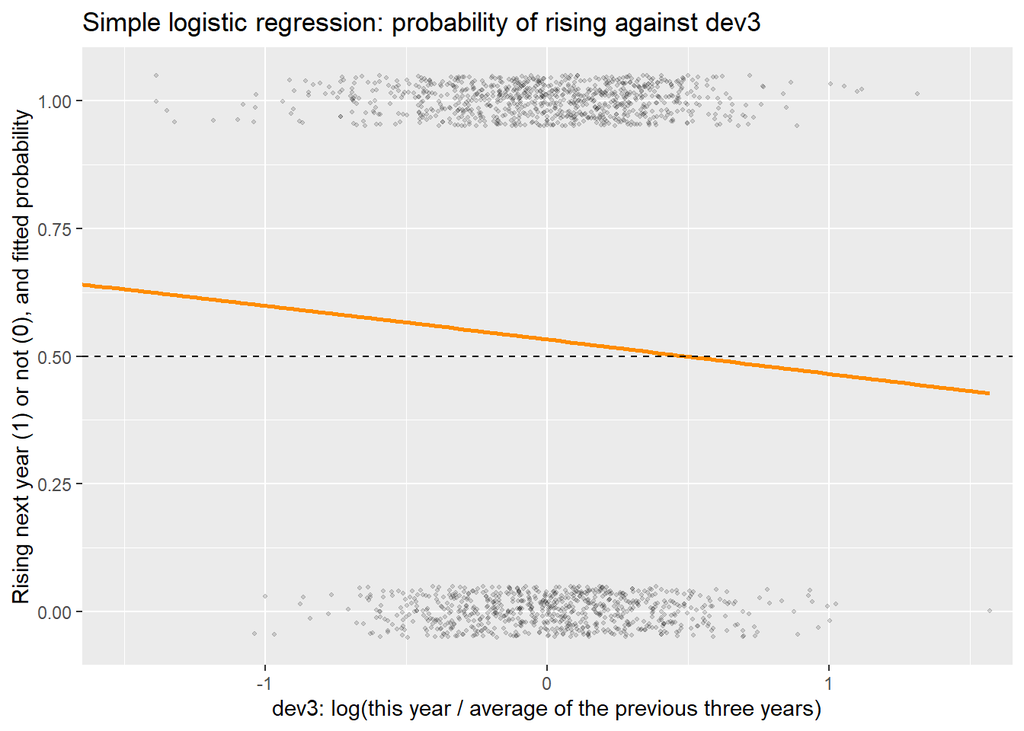

```r
ggplot(df_train, aes(x = dev3, y = rising)) +
  geom_jitter(height = 0.05, width = 0, alpha = 0.15, size = 0.8) +
  geom_function(fun = function(x) exp(b0 + b1 * x) / (1 + exp(b0 + b1 * x)),
                colour = "darkorange", linewidth = 1) +
  geom_hline(yintercept = 0.5, linetype = "dashed") +
  coord_cartesian(xlim = c(-1.5, 1.5)) +
  labs(title = "Simple logistic regression: probability of rising against dev3",
       x = "dev3: log(this year / average of the previous three years)",
       y = "Rising next year (1) or not (0), and fitted probability")
```

```r
results <- add_result(results, "Logistic regression, dev3 only", "logistic",
                      as.integer(pred_simple > 0.5), pred_simple)
```

```r
round(class_metrics(as.integer(pred_simple > 0.5), df_test$rising), 3)
```

```
##    accuracy sensitivity specificity   precision
##       0.473       0.923       0.104       0.458
```

```r
cat("Test rows predicted to rise:", sum(pred_simple > 0.5), "of", nrow(df_test), "\n")
```

```
## Test rows predicted to rise: 365 of 402
```

```r
cat("dev3 at which the fitted probability crosses 0.5:", round(-b0 / b1, 3), "\n")
```

```
## dev3 at which the fitted probability crosses 0.5: 0.488
```

The fitted curve is almost flat and only crosses 0.5 at `dev3` = 0.49, so the model calls a rise for every district-year that is less than about 63% above its three-year average — nearly all of them. On the test set that is 47% accurate, worse than the pencil rule built on the same feature. The two differ only in where they cut: the rule cuts at zero, and the model cuts where the training years, with their 53% of rises, told it to. The lesson carries through the rest of the document: a classifier inherits the class balance of the years it was trained on, and the test years lean the other way.

## 3.2 Multiple logistic regression

All nine features go in the same way they would into `lm()`.

```r
logreg.fit <- glm(rising ~ g1 + dev3 + h2_h1 + log_dwell + multi_share +
                    alt_share + nonres_share + cv5 + nat_g1,
                  data = df_train, family = binomial)
summary(logreg.fit)
```

```
##
## Call:
## glm(formula = rising ~ g1 + dev3 + h2_h1 + log_dwell + multi_share +
##     alt_share + nonres_share + cv5 + nat_g1, family = binomial,
##     data = df_train)
##
## Coefficients:
##              Estimate Std. Error z value Pr(>|z|)
## (Intercept)  -1.33029    0.42119  -3.158  0.00159 **
## g1           -0.86531    0.26799  -3.229  0.00124 **
## dev3          0.45917    0.23992   1.914  0.05564 .
## h2_h1         0.75929    0.15052   5.044 4.55e-07 ***
## log_dwell     0.19051    0.05929   3.213  0.00131 **
## multi_share  -2.11031    0.45784  -4.609 4.04e-06 ***
## alt_share     2.84785    0.68738   4.143 3.43e-05 ***
## nonres_share  0.46690    0.38165   1.223  0.22119
## cv5          -0.31632    0.43000  -0.736  0.46196
## nat_g1        0.96301    0.33571   2.869  0.00412 **
## ---
## Signif. codes:  0 '***' 0.001 '**' 0.01 '*' 0.05 '.' 0.1 ' ' 1
##
## (Dispersion parameter for binomial family taken to be 1)
##
##     Null deviance: 2220.9  on 1606  degrees of freedom
## Residual deviance: 2129.5  on 1597  degrees of freedom
## AIC: 2149.5
##
## Number of Fisher Scoring iterations: 4
```

The coefficients are on different scales because the features are. To compare them, each is multiplied by its feature’s standard deviation: the change in the log-odds of rising when the feature goes up by one standard deviation.

```r
std_coef <- coef(logreg.fit)[features] * sapply(df_train[features], sd)

tibble(feature = features,
       coefficient = coef(logreg.fit)[features],
       per_sd = std_coef,
       p_value = summary(logreg.fit)$coefficients[features, "Pr(>|z|)"]) %>%
  arrange(desc(abs(per_sd))) %>%
  mutate(coefficient = round(coefficient, 3), per_sd = round(per_sd, 3),
         p_value = signif(p_value, 2)) %>%
  knitr::kable(caption = "Multiple logistic regression: coefficients, and their size per standard deviation of the feature")
```

Multiple logistic regression: coefficients, and their size per standard deviation of the feature

| feature | coefficient | per_sd | p_value |
| --- | --- | --- | --- |
| alt_share | 2.848 | 0.362 | 3.4e-05 |
| g1 | -0.865 | -0.295 | 1.2e-03 |
| multi_share | -2.110 | -0.288 | 4.0e-06 |
| h2_h1 | 0.759 | 0.280 | 5.0e-07 |
| log_dwell | 0.191 | 0.272 | 1.3e-03 |
| dev3 | 0.459 | 0.171 | 5.6e-02 |
| nat_g1 | 0.963 | 0.158 | 4.1e-03 |
| nonres_share | 0.467 | 0.081 | 2.2e-01 |
| cv5 | -0.316 | -0.043 | 4.6e-01 |

Six of the nine features are significant at the 5% level, and their signs tell a consistent story.

- `g1` is negative: a district that grew this year is less likely to grow again. This is the mean reversion of section 2, now carried by `g1`; with `g1` in the model, `dev3` changes sign and is no longer significant ($p = 0.056$), because the two measure nearly the same thing.
- `h2_h1` is positive: a year that finished stronger than it started tends to carry on. Momentum within the year and reversion between years are both present.
- `alt_share` is positive and `multi_share` negative: districts doing relatively more work on existing homes, and building relatively fewer multi-unit dwellings, are more likely to rise. Both are probably signs of a market that is low at the moment and has room to recover.
- `log_dwell` and `nat_g1` are positive: larger markets, and years in which the country as a whole grew, lean towards a rise.
- `nonres_share` and `cv5` do nothing.

None of the effects is large. The biggest, `alt_share`, changes the log-odds by 0.36 per standard deviation, which multiplies the odds of a rise by about 1.4.

## 3.3 Evaluating performance

```r
# make predictions with the built-in function
pred_prob <- predict(logreg.fit, newdata = df_test, type = "response")

# change the predictions from probabilities to classes
pred_class <- ifelse(pred_prob > 0.5, 1, 0)

# form a confusion matrix
conf <- table(Predicted = pred_class, Actual = df_test$rising)
conf
```

```
##          Actual
## Predicted   0   1
##         0 165  99
##         1  56  82
```

Everything else is read off those four cells. Computing them from the table by position, then checking against the helper used for every other model:

```r
TN <- conf["0", "0"]
FN <- conf["0", "1"]
FP <- conf["1", "0"]
TP <- conf["1", "1"]
total <- TP + TN + FP + FN

paste("Accuracy:", round((TP + TN) / total, 4))
```

```
## [1] "Accuracy: 0.6144"
```

```r
paste("Misclassification rate:", round((FP + FN) / total, 4))
```

```
## [1] "Misclassification rate: 0.3856"
```

```r
paste("Sensitivity (recall):", round(TP / (TP + FN), 4))
```

```
## [1] "Sensitivity (recall): 0.453"
```

```r
paste("Specificity:", round(TN / (TN + FP), 4))
```

```
## [1] "Specificity: 0.7466"
```

```r
paste("Precision:", round(TP / (TP + FP), 4))
```

```
## [1] "Precision: 0.5942"
```

```r
round(class_metrics(pred_class, df_test$rising), 4)
```

```
##    accuracy sensitivity specificity   precision
##      0.6144      0.4530      0.7466      0.5942
```

The model is right for 247 of the 402 test district-years, 61.4%. It is better at falls than at rises: it catches three-quarters of the falls (specificity 0.75) and under half of the rises (sensitivity 0.45). When it does call a rise, it is right 59% of the time (precision).

```r
results <- add_result(results, "Logistic regression, 9 features", "logistic",
                      as.integer(pred_class), pred_prob)
```

## 3.4 Thresholds, ROC and AUC

The 0.5 threshold is a choice. Lowering it calls more district-years Rise, which catches more of the real rises (sensitivity up) at the cost of more false alarms (specificity down).

```r
map_dfr(c(0.4, 0.45, 0.5, 0.55, 0.6), function(threshold) {
  m <- class_metrics(as.integer(pred_prob > threshold), df_test$rising)
  tibble(threshold = threshold, predicted_rise = sum(pred_prob > threshold),
         accuracy = m[["accuracy"]], sensitivity = m[["sensitivity"]],
         specificity = m[["specificity"]], precision = m[["precision"]])
}) %>%
  mutate(across(-c(threshold, predicted_rise), ~ round(.x, 3))) %>%
  knitr::kable(caption = "Multiple logistic regression on the test set at five thresholds")
```

Multiple logistic regression on the test set at five thresholds

| threshold | predicted_rise | accuracy | sensitivity | specificity | precision |
| --- | --- | --- | --- | --- | --- |
| 0.40 | 262 | 0.560 | 0.735 | 0.416 | 0.508 |
| 0.45 | 204 | 0.580 | 0.597 | 0.566 | 0.529 |
| 0.50 | 138 | 0.614 | 0.453 | 0.747 | 0.594 |
| 0.55 | 77 | 0.602 | 0.271 | 0.873 | 0.636 |
| 0.60 | 36 | 0.595 | 0.149 | 0.959 | 0.750 |

Moving the threshold trades one kind of error for the other without improving accuracy: 0.5 is the best of the five, at 0.4 the model calls 262 rises and catches 74% of the real ones, and at 0.6 it calls only 36.

The ROC curve shows that trade-off at every threshold at once, and the area under it (AUC) summarises it in one number: 0.5 for a model no better than chance, 1 for a perfect one.

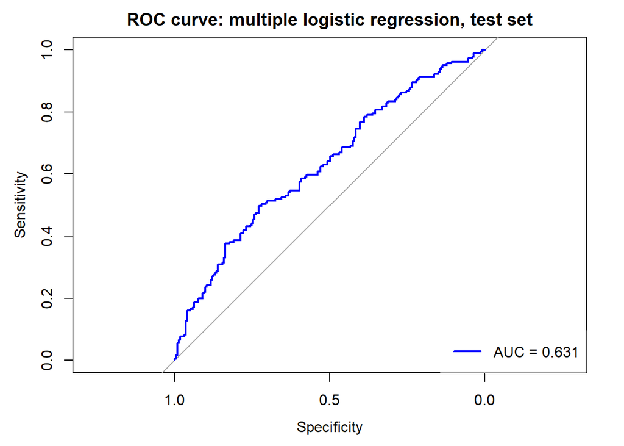

```r
roc_log <- roc(df_test$rising, pred_prob, levels = c(0, 1), direction = "<", quiet = TRUE)

plot(roc_log, col = "blue", main = "ROC curve: multiple logistic regression, test set")
legend("bottomright", legend = paste("AUC =", round(auc(roc_log), 3)),
       col = "blue", lwd = 2, box.lty = 0)
```

The AUC is 0.63: the curve sits a little above the diagonal along its whole length. If one rising and one falling district-year are picked at random, the model gives the higher probability to the rising one 63% of the time.

**The threshold stays at 0.5 for every model.** Choosing it by looking at the test set would be tuning on the test set. Neither kind of error is obviously worse here — predicting a rise that does not come and missing one that does are both simply wrong — so there is no case for moving it on other grounds. The table above is for information only.

# 4 Discriminant analysis

Discriminant analysis comes at the same problem from the other side. Instead of modelling the probability of the class given the features, it models the features within each class as normally distributed, and assigns a new observation to the class with the higher discriminant score. For one feature the score of class $k$ is

$$\delta_k(x) = -\frac{(x -
m_k)^2}{2\sigma_k^2} - \log\sigma_k + \log\pi_k$$

where $m_k$ and $\sigma_k^2$ are the mean and variance of the feature in class $k$ and $\pi_k$ is the share of the training data in that class. Quadratic discriminant analysis (QDA) gives each class its own variance; linear discriminant analysis (LDA) makes them share one.

## 4.1 QDA with one feature, by hand

```r
rise <- df_train %>% dplyr::filter(rising == 1) %>% pull(dev3)
fall <- df_train %>% dplyr::filter(rising == 0) %>% pull(dev3)

# prior probability, mean and variance of dev3 in each class
pi_rise <- length(rise) / nrow(df_train)
pi_fall <- length(fall) / nrow(df_train)
m_rise <- mean(rise)
m_fall <- mean(fall)
var_rise <- var(rise)
var_fall <- var(fall)

round(c(pi_rise = pi_rise, m_rise = m_rise, sd_rise = sqrt(var_rise),
        pi_fall = pi_fall, m_fall = m_fall, sd_fall = sqrt(var_fall)), 4)
```

```
## pi_rise  m_rise sd_rise pi_fall  m_fall sd_fall
##  0.5327 -0.0150  0.3888  0.4673  0.0221  0.3501
```

```r
# discriminant score function for each class
delta_rise <- function(x) -(x - m_rise)^2 / (2 * var_rise) - log(sqrt(var_rise)) + log(pi_rise)
delta_fall <- function(x) -(x - m_fall)^2 / (2 * var_fall) - log(sqrt(var_fall)) + log(pi_fall)
```

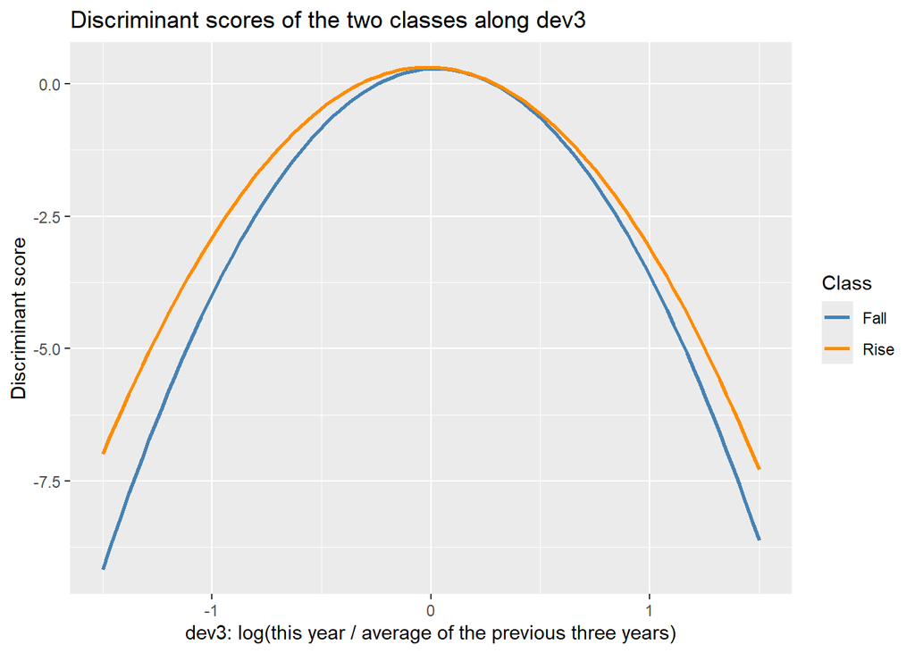

```r
ggplot() +
  geom_function(fun = delta_fall, aes(color = "Fall"), linewidth = 1) +
  geom_function(fun = delta_rise, aes(color = "Rise"), linewidth = 1) +
  scale_color_manual(values = c("Fall" = "steelblue", "Rise" = "darkorange")) +
  scale_x_continuous(limits = c(-1.5, 1.5)) +
  labs(title = "Discriminant scores of the two classes along dev3",
       x = "dev3: log(this year / average of the previous three years)",
       y = "Discriminant score", color = "Class")
```

Whichever curve is higher at a given `dev3` is the class we assign. Wrapping that rule in a function gives a hand-built QDA model, which should agree with `qda()` from `MASS` on every test row.

```r
# assign the class with the higher discriminant score
qda_by_hand <- ifelse(delta_rise(df_test$dev3) > delta_fall(df_test$dev3), 1, 0)

# the built-in function on the same single feature
qda.simple <- qda(direction ~ dev3, data = df_train)
qda_builtin <- ifelse(predict(qda.simple, newdata = df_test)$class == "Rise", 1, 0)

paste("Test rows where the hand-built and built-in QDA agree:",
      sum(qda_by_hand == qda_builtin), "of", nrow(df_test))
```

```
## [1] "Test rows where the hand-built and built-in QDA agree: 402 of 402"
```

```r
paste("Test rows the one-feature QDA assigns to Rise:", sum(qda_by_hand), "of", nrow(df_test))
```

```
## [1] "Test rows the one-feature QDA assigns to Rise: 402 of 402"
```

```r
paste("Accuracy of the one-feature QDA:", round(mean(qda_by_hand == df_test$rising), 4))
```

```
## [1] "Accuracy of the one-feature QDA: 0.4502"
```

The hand-built model and `qda()` agree on all 402 test rows, so the formula is doing what the function does. As a classifier it is no use: the two classes have almost the same mean of `dev3` (−0.015 and 0.022) and almost the same spread (0.39 and 0.35), so the two score curves lie nearly on top of each other and the Rise curve, lifted by its larger prior, is the higher one across the whole range where the data lies. One feature is not enough for either method.

## 4.2 LDA and QDA with all nine features

```r
train_da <- df_train %>% dplyr::select(direction, all_of(features))
test_da  <- df_test  %>% dplyr::select(direction, all_of(features))

lda.fit <- lda(direction ~ ., data = train_da)
lda.fit
```

```
## Call:
## lda(direction ~ ., data = train_da)
##
## Prior probabilities of groups:
##      Fall      Rise
## 0.4673304 0.5326696
##
## Group means:
##               g1        dev3     h2_h1 log_dwell multi_share alt_share
## Fall  0.04368711  0.02209252 0.0396578  4.822706   0.1451304 0.2293568
## Rise -0.01264176 -0.01503611 0.1289295  4.695241   0.1181679 0.2575628
##      nonres_share       cv5      nat_g1
## Fall    0.3236506 0.2666571 0.005311177
## Rise    0.3492169 0.2625716 0.023474991
##
## Coefficients of linear discriminants:
##                     LD1
## g1           -1.6726622
## dev3          0.9151565
## h2_h1         1.4976905
## log_dwell     0.3757823
## multi_share  -4.2429798
## alt_share     5.4390091
## nonres_share  0.9477756
## cv5          -0.6787975
## nat_g1        1.9307132
```

`lda()` prints the prior probabilities, the class means of each feature and the coefficients of the single linear discriminant — the weighted sum of the features along which the two classes are furthest apart. The coefficients have the same signs as the logistic regression’s and are close to twice their size throughout (`g1` −1.67 against −0.87, `h2_h1` 1.50 against 0.76, `alt_share` 5.44 against 2.85): the two methods have found the same direction in the data and scaled it differently.

```r
qda.fit <- qda(direction ~ ., data = train_da)

# use $class to extract the predicted classes, $posterior for the class probabilities
pred_lda <- predict(lda.fit, newdata = test_da)
pred_qda <- predict(qda.fit, newdata = test_da)

table(Predicted = pred_lda$class, Actual = test_da$direction)
```

```
##          Actual
## Predicted Fall Rise
##      Fall  162   97
##      Rise   59   84
```

```r
table(Predicted = pred_qda$class, Actual = test_da$direction)
```

```
##          Actual
## Predicted Fall Rise
##      Fall  128   72
##      Rise   93  109
```

```r
prob_lda <- pred_lda$posterior[, "Rise"]
prob_qda <- pred_qda$posterior[, "Rise"]

results <- results %>%
  add_result("LDA, 9 features", "discriminant", as.integer(pred_lda$class == "Rise"), prob_lda) %>%
  add_result("QDA, 9 features", "discriminant", as.integer(pred_qda$class == "Rise"), prob_qda)

results %>%
  dplyr::filter(family != "rule of thumb") %>%
  mutate(across(where(is.numeric), ~ round(.x, 3))) %>%
  knitr::kable(caption = "Logistic regression and discriminant analysis on the test set")
```

Logistic regression and discriminant analysis on the test set

| model | family | accuracy | sensitivity | specificity | precision | AUC |
| --- | --- | --- | --- | --- | --- | --- |
| Logistic regression, dev3 only | logistic | 0.473 | 0.923 | 0.104 | 0.458 | 0.588 |
| Logistic regression, 9 features | logistic | 0.614 | 0.453 | 0.747 | 0.594 | 0.631 |
| LDA, 9 features | discriminant | 0.612 | 0.464 | 0.733 | 0.587 | 0.629 |
| QDA, 9 features | discriminant | 0.590 | 0.602 | 0.579 | 0.540 | 0.621 |

```r
# how often LDA and logistic regression make the same call on the test set
paste("LDA and logistic regression agree on", sum((prob_lda > 0.5) == (pred_prob > 0.5)),
      "of", nrow(df_test), "test rows")
```

```
## [1] "LDA and logistic regression agree on 395 of 402 test rows"
```

```r
paste("QDA and LDA agree on", sum((prob_qda > 0.5) == (prob_lda > 0.5)), "of", nrow(df_test))
```

```
## [1] "QDA and LDA agree on 305 of 402"
```

```r
# the standard deviation of each feature within each class: LDA assumes these are equal
train_da %>%
  group_by(direction) %>%
  summarise(across(all_of(features), sd)) %>%
  pivot_longer(-direction, names_to = "feature", values_to = "sd") %>%
  pivot_wider(names_from = direction, values_from = sd) %>%
  mutate(ratio = Rise / Fall, across(where(is.numeric), ~ round(.x, 3))) %>%
  knitr::kable(caption = "Standard deviation of each feature within each class (training rows)")
```

Standard deviation of each feature within each class (training rows)

| feature | Fall | Rise | ratio |
| --- | --- | --- | --- |
| g1 | 0.342 | 0.339 | 0.991 |
| dev3 | 0.350 | 0.389 | 1.110 |
| h2_h1 | 0.394 | 0.340 | 0.863 |
| log_dwell | 1.398 | 1.450 | 1.037 |
| multi_share | 0.145 | 0.127 | 0.882 |
| alt_share | 0.114 | 0.136 | 1.192 |
| nonres_share | 0.168 | 0.179 | 1.070 |
| cv5 | 0.138 | 0.133 | 0.967 |
| nat_g1 | 0.169 | 0.160 | 0.949 |

LDA is right for 246 of 402 (61.2%) and makes the same call as the logistic regression on 395 of them. That is expected: both draw a straight boundary through the features, and they differ only in how they estimate it.

QDA is right for 237 (59.0%) and behaves differently, agreeing with LDA on only 305 rows. It calls many more rises (202 against 143), so it catches more of them (sensitivity 0.60 against 0.46) and misses more falls. The last table explains why its extra flexibility does not pay: LDA assumes each feature has the same spread in both classes, and here the two spreads are within 20% of each other on every feature. QDA estimates a separate covariance matrix for each class — 45 extra numbers — to model a difference that is barely there.

# 5 Tree-based models

A classification tree splits the training rows on one feature at a time, choosing each split to make the two sides as pure in class as it can, and predicts the majority class of the leaf a new row lands in. Trees find thresholds and interactions without being told where to look. As in RQ1 the tree-based models are also given `region`, coded with short labels so that a split on several regions fits on the plot.

```r
region_short <- c("Northland Region" = "Nthld", "Auckland Region" = "Akl",
                  "Waikato Region" = "Wkto", "Bay of Plenty Region" = "BoP",
                  "Gisborne Region" = "Gis", "Hawke's Bay Region" = "HB",
                  "Taranaki Region" = "Tnki", "Manawatu-Whanganui Region" = "MWh",
                  "Wellington Region" = "Wgtn", "Tasman Region" = "Tas",
                  "Nelson Region" = "Nsn", "Marlborough Region" = "Marl",
                  "West Coast Region" = "WC", "Canterbury Region" = "Cant",
                  "Otago Region" = "Otago", "Southland Region" = "Sthld",
                  "Area Outside Region" = "Chat")

# data.frames rather than tibbles: gbm() in particular wants the base class
make_tree_data <- function(d) {
  d %>%
    dplyr::select(direction, all_of(features), region) %>%
    mutate(region = factor(region_short[as.character(region)], levels = unname(region_short))) %>%
    as.data.frame()
}

train_tree <- make_tree_data(df_train)
test_tree  <- make_tree_data(df_test)

stopifnot(!anyNA(train_tree$region), !anyNA(test_tree$region))
dim(train_tree)
```

```
## [1] 1607   11
```

## 5.1 Classification tree

```r
class.tree <- tree(direction ~ ., data = train_tree)
summary(class.tree)
```

```
##
## Classification tree:
## tree(formula = direction ~ ., data = train_tree)
## Variables actually used in tree construction:
## [1] "nat_g1"    "h2_h1"     "alt_share"
## Number of terminal nodes:  4
## Residual mean deviance:  1.317 = 2111 / 1603
## Misclassification error rate: 0.3958 = 636 / 1607
```

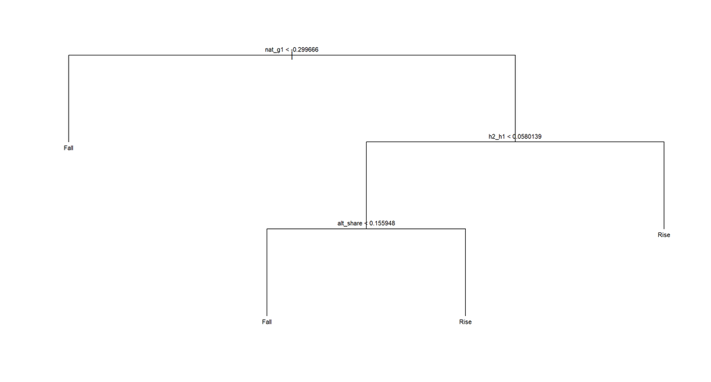

```r
# type = "uniform" gives every level the same height, so the lower splits can be read
plot(class.tree, type = "uniform")
text(class.tree, pretty = 0, cex = 0.7)
```

The split at the top is the single most useful yes/no question the tree could find about a district-year; each leaf is labelled with the class it predicts. `summary()` gives the misclassification rate on the training rows, which flatters the tree because it was grown on those rows. The test set is the honest check.

```r
# predicted class, and the predicted probability of Rise for the ROC curve
pred_tree_class <- predict(class.tree, newdata = test_tree, type = "class")
prob_tree       <- predict(class.tree, newdata = test_tree)[, "Rise"]

# compute the error rate
class.er <- mean(pred_tree_class != test_tree$direction)
paste("Test error rate of the full tree:", round(class.er, 4))
```

```
## [1] "Test error rate of the full tree: 0.4975"
```

```r
results <- add_result(results, "Classification tree (full)", "tree-based",
                      as.integer(pred_tree_class == "Rise"), prob_tree)
```

## 5.2 Pruning

A large tree fits the training rows closely and generalises poorly. Module 6 prunes by cross-validation: `cv.tree()` with `FUN = prune.misclass` reports the cross-validated number of misclassified rows for each tree size, and we cut the tree back to the size with the fewest.

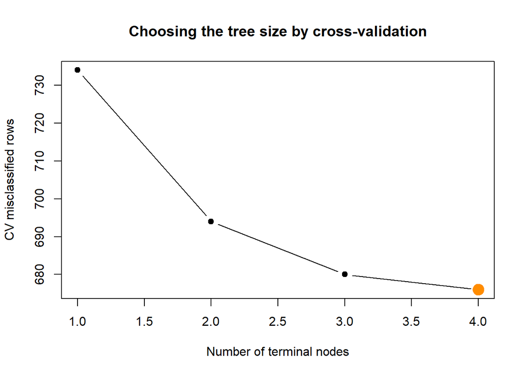

```r
set.seed(462)
cv.class <- cv.tree(class.tree, FUN = prune.misclass)

# the best size among trees with at least two leaves: a one-leaf "tree" cannot be plotted
candidates <- cv.class$size >= 2
best.size <- cv.class$size[candidates][which.min(cv.class$dev[candidates])]

plot(cv.class$size, cv.class$dev, type = "b", pch = 19,
     xlab = "Number of terminal nodes", ylab = "CV misclassified rows",
     main = "Choosing the tree size by cross-validation")
points(best.size, min(cv.class$dev[candidates]), col = "darkorange", pch = 19, cex = 2)
```

```r
cat("Tree sizes tried:", cv.class$size, "\n")
```

```
## Tree sizes tried: 4 3 2 1
```

```r
cat("CV misclassified:", cv.class$dev, "\n")
```

```
## CV misclassified: 676 680 694 734
```

```r
cat("Chosen size:", best.size, "\n")
```

```
## Chosen size: 4
```

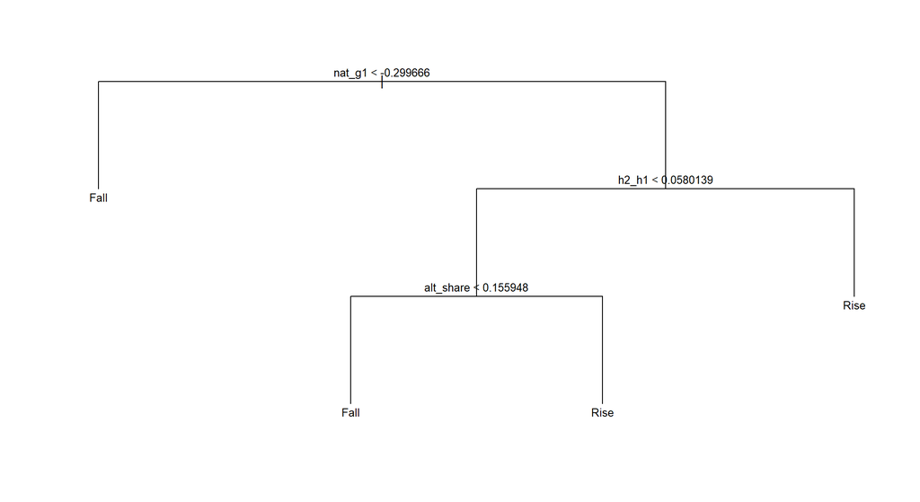

```r
# use the best size to prune the tree
pruned.tree <- prune.misclass(class.tree, best = best.size)

plot(pruned.tree, type = "uniform")
text(pruned.tree, pretty = 0, cex = 0.8)
```

If the cross-validation curve is nearly flat, that is a finding in itself: no size of tree is clearly better than another, which is what happens when the splits below the first few are fitting noise.

```r
pred_pruned_class <- predict(pruned.tree, newdata = test_tree, type = "class")
prob_pruned       <- predict(pruned.tree, newdata = test_tree)[, "Rise"]

pruned.er <- mean(pred_pruned_class != test_tree$direction)
paste("Test error rate: full tree", round(class.er, 4), " pruned tree", round(pruned.er, 4))
```

```
## [1] "Test error rate: full tree 0.4975  pruned tree 0.4975"
```

```r
results <- add_result(results, paste0("Classification tree (pruned, ", best.size, " leaves)"),
                      "tree-based", as.integer(pred_pruned_class == "Rise"), prob_pruned)
```

**A caution about `cv.tree()` here.** Its folds are drawn at random from the training rows, so rows from the same year land in different folds, and a tree tested on 2008 rows has usually seen other 2008 rows. Because districts move together within a year, that makes the cross-validated error look better than a forecast of a new year would be. It is the Module 6 recipe and it is fine for choosing a size, but the test set, not the CV curve, is the measure of how well the tree forecasts.

## 5.3 Bagging and random forest

Bagging grows many trees on bootstrap samples of the training rows and lets them vote; a random forest does the same but offers each split only a random subset of the features, which makes the trees less alike. In `randomForest()` the difference is `mtry`: all ten predictors for bagging, three (about the square root of ten) for a classification forest.

```r
num_predictors <- ncol(train_tree) - 1     # 9 features + region

set.seed(462)
bag.tree <- randomForest(direction ~ ., data = train_tree,
                         mtry = num_predictors, ntree = 500, importance = TRUE)
set.seed(462)
rf.tree  <- randomForest(direction ~ ., data = train_tree,
                         mtry = 3, ntree = 500, importance = TRUE)
bag.tree
```

```
##
## Call:
##  randomForest(formula = direction ~ ., data = train_tree, mtry = num_predictors,      ntree = 500, importance = TRUE)
##                Type of random forest: classification
##                      Number of trees: 500
## No. of variables tried at each split: 10
##
##         OOB estimate of  error rate: 38.02%
## Confusion matrix:
##      Fall Rise class.error
## Fall  381  370   0.4926764
## Rise  241  615   0.2815421
```

```r
rf.tree
```

```
##
## Call:
##  randomForest(formula = direction ~ ., data = train_tree, mtry = 3,      ntree = 500, importance = TRUE)
##                Type of random forest: classification
##                      Number of trees: 500
## No. of variables tried at each split: 3
##
##         OOB estimate of  error rate: 37.27%
## Confusion matrix:
##      Fall Rise class.error
## Fall  380  371   0.4940080
## Rise  228  628   0.2663551
```

The printed OOB (out-of-bag) error is each training row classified only by the trees that did not see it. Both ensembles have an OOB error of about 37–38%, and both confusion matrices show the pattern of the simple logistic model: they are much better at rises than falls on the training rows, because rises are the more common class there. The OOB figure carries the same same-year caveat as `cv.tree()`, so the test error below is the one to trust.

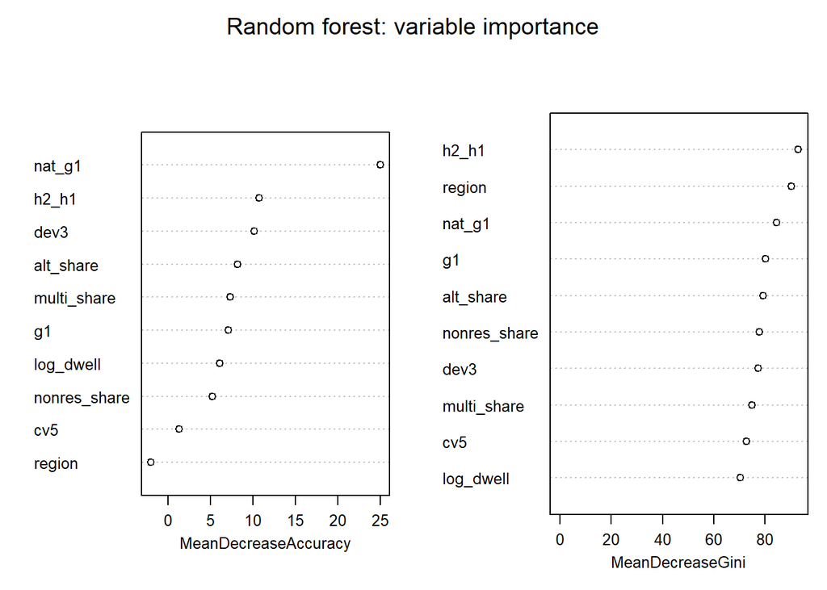

```r
varImpPlot(rf.tree, main = "Random forest: variable importance", cex = 0.8)
```

```r
pred_bag_class <- predict(bag.tree, newdata = test_tree)
prob_bag       <- predict(bag.tree, newdata = test_tree, type = "prob")[, "Rise"]
pred_rf_class  <- predict(rf.tree,  newdata = test_tree)
prob_rf        <- predict(rf.tree,  newdata = test_tree, type = "prob")[, "Rise"]

bag.er <- mean(pred_bag_class != test_tree$direction)
rf.er  <- mean(pred_rf_class  != test_tree$direction)
paste("Test error rate: bagging", round(bag.er, 4), " random forest", round(rf.er, 4))
```

```
## [1] "Test error rate: bagging 0.4204  random forest 0.4129"
```

```r
results <- results %>%
  add_result("Bagging (mtry = 10)",      "tree-based", as.integer(pred_bag_class == "Rise"), prob_bag) %>%
  add_result("Random forest (mtry = 3)", "tree-based", as.integer(pred_rf_class == "Rise"),  prob_rf)
```

On the test set both ensembles are wrong about 41–42% of the time, a few points worse than their OOB estimates suggested. The importance plot puts `nat_g1` first by a wide margin on the accuracy measure; section 6.6 compares that ranking with the other models’.

## 5.4 Boosting

Boosting grows small trees one after another, each concentrating on the rows the ensemble so far gets wrong, and adds them up scaled by the shrinkage. `gbm()` wants the class as a number, 0 or 1, and `distribution = "bernoulli"` for a two-class problem. The number of trees is what decides between underfitting and overfitting, so we choose it by cross-validation — with folds made of blocks of years, as in RQ1, so that every fold is a set of years the model has not seen.

```r
train_gbm <- train_tree %>%
  mutate(rising = as.integer(direction == "Rise")) %>%
  dplyr::select(-direction)
test_gbm <- test_tree %>%
  mutate(rising = as.integer(direction == "Rise")) %>%
  dplyr::select(-direction)

# five blocks of training years: 1995-99, 2000-04, 2005-09, 2010-14, 2015-18
fold_id <- cut(df_train$year, breaks = c(1994, 1999, 2004, 2009, 2014, 2018), labels = FALSE)
table(fold_id)
```

```
## fold_id
##   1   2   3   4   5
## 334 335 335 335 268
```

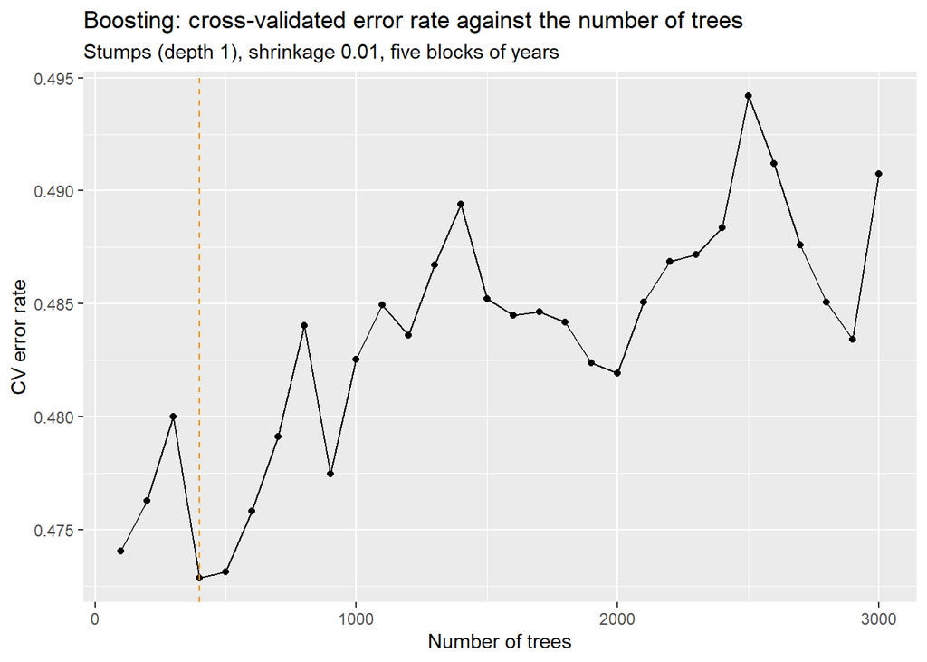

```r
tree_grid <- seq(100, 3000, by = 100)

# for each block: fit on the other four, record the error rate on the block at every number of trees
cv_error <- sapply(1:5, function(k) {
  set.seed(462)
  fit <- gbm(rising ~ ., data = train_gbm[fold_id != k, ],
             distribution = "bernoulli", n.trees = max(tree_grid),
             interaction.depth = 1, shrinkage = 0.01, verbose = FALSE)
  prob <- predict(fit, newdata = train_gbm[fold_id == k, ], n.trees = tree_grid, type = "response")
  colMeans((prob > 0.5) != train_gbm$rising[fold_id == k])
})

cv_boost <- tibble(n_trees = tree_grid, cv_error = rowMeans(cv_error))
best_trees <- cv_boost$n_trees[which.min(cv_boost$cv_error)]

ggplot(cv_boost, aes(x = n_trees, y = cv_error)) +
  geom_line() +
  geom_point() +
  geom_vline(xintercept = best_trees, colour = "darkorange", linetype = "dashed") +
  labs(title = "Boosting: cross-validated error rate against the number of trees",
       subtitle = "Stumps (depth 1), shrinkage 0.01, five blocks of years",
       x = "Number of trees", y = "CV error rate")
```

```r
cat("Number of trees with the lowest CV error:", best_trees,
    " CV error:", round(min(cv_boost$cv_error), 4), "\n")
```

```
## Number of trees with the lowest CV error: 400  CV error: 0.4729
```

Read the vertical axis before the shape. On blocks of years it has not seen, the boosted model is wrong about 47–49% of the time whatever the number of trees: barely better than a coin. The whole curve spans about two percentage points, so the number of trees it picks is the lowest point of a nearly flat line. This is the first sight of a result that section 6.4 looks at directly.

```r
set.seed(462)
boost.fit <- gbm(rising ~ ., data = train_gbm,
                 distribution = "bernoulli", n.trees = best_trees,
                 interaction.depth = 1, shrinkage = 0.01, verbose = FALSE)

# relative influence: share of the total improvement attributed to each feature
summary(boost.fit, plotit = FALSE) %>%
  mutate(rel.inf = round(rel.inf, 2)) %>%
  knitr::kable(row.names = FALSE, caption = "Boosting: relative influence of each feature")
```

Boosting: relative influence of each feature

| var | rel.inf |
| --- | --- |
| h2_h1 | 26.39 |
| nat_g1 | 25.89 |
| multi_share | 13.10 |
| alt_share | 9.28 |
| g1 | 8.57 |
| dev3 | 6.04 |
| region | 5.50 |
| nonres_share | 4.53 |
| log_dwell | 0.53 |
| cv5 | 0.18 |

```r
prob_boost <- predict(boost.fit, newdata = test_gbm, n.trees = best_trees, type = "response")
boost.pred <- ifelse(prob_boost >= 0.5, 1, 0)

paste("Test error rate of the boosted model:", round(mean(boost.pred != test_gbm$rising), 4))
```

```
## [1] "Test error rate of the boosted model: 0.4005"
```

```r
results <- add_result(results, paste0("Boosting (", best_trees, " stumps)"), "tree-based",
                      as.integer(boost.pred), prob_boost)
```

On the test set the boosted model is wrong about 40% of the time, close to the logistic regression. Its relative influence table is led by `h2_h1` and `nat_g1`, which together account for about half of the total.

# 6 Evaluate performance

## 6.1 Every model on the same test set

```r
results_test <- results %>%
  arrange(desc(accuracy)) %>%
  mutate(rank = row_number()) %>%
  dplyr::select(rank, model, family, accuracy, sensitivity, specificity, precision, AUC)

results_test %>%
  mutate(across(where(is.numeric) & !rank, ~ round(.x, 3))) %>%
  knitr::kable(caption = "Every model and rule of thumb on the same 402 test district-years, most accurate first")
```

Every model and rule of thumb on the same 402 test district-years, most accurate first

| rank | model | family | accuracy | sensitivity | specificity | precision | AUC |
| --- | --- | --- | --- | --- | --- | --- | --- |
| 1 | Logistic regression, 9 features | logistic | 0.614 | 0.453 | 0.747 | 0.594 | 0.631 |
| 2 | LDA, 9 features | discriminant | 0.612 | 0.464 | 0.733 | 0.587 | 0.629 |
| 3 | Boosting (400 stumps) | tree-based | 0.600 | 0.558 | 0.633 | 0.555 | 0.631 |
| 4 | QDA, 9 features | discriminant | 0.590 | 0.602 | 0.579 | 0.540 | 0.621 |
| 5 | Random forest (mtry = 3) | tree-based | 0.587 | 0.569 | 0.602 | 0.539 | 0.603 |
| 6 | Below own 3-year average: rise | rule of thumb | 0.585 | 0.575 | 0.593 | 0.536 | NA |
| 7 | Bagging (mtry = 10) | tree-based | 0.580 | 0.530 | 0.620 | 0.533 | 0.588 |
| 8 | Opposite direction to this year | rule of thumb | 0.540 | 0.602 | 0.489 | 0.491 | NA |
| 9 | Classification tree (full) | tree-based | 0.502 | 0.768 | 0.285 | 0.468 | 0.539 |
| 10 | Classification tree (pruned, 4 leaves) | tree-based | 0.502 | 0.768 | 0.285 | 0.468 | 0.539 |
| 11 | Logistic regression, dev3 only | logistic | 0.473 | 0.923 | 0.104 | 0.458 | 0.588 |
| 12 | Same direction as this year | rule of thumb | 0.460 | 0.398 | 0.511 | 0.400 | NA |
| 13 | Always the more common class in training | rule of thumb | 0.450 | 1.000 | 0.000 | 0.450 | NA |

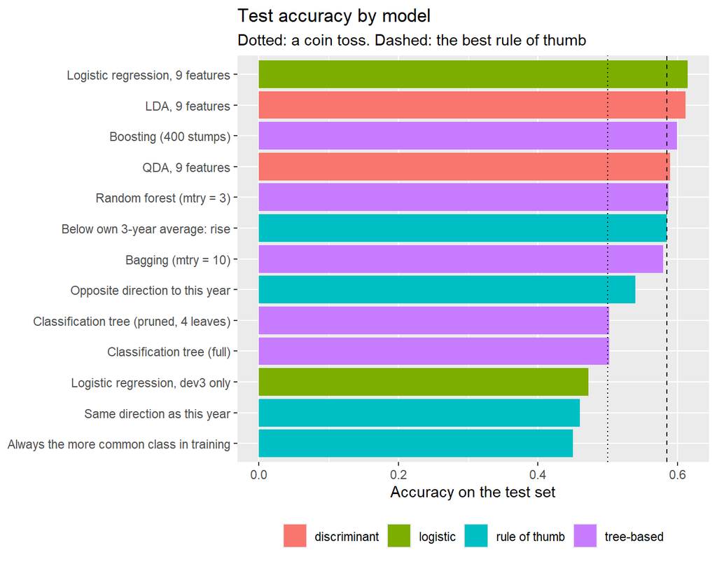

```r
best_rule <- max(results$accuracy[results$family == "rule of thumb"])

results_test %>%
  mutate(model = fct_reorder(model, accuracy)) %>%
  ggplot(aes(x = model, y = accuracy, fill = family)) +
  geom_col() +
  coord_flip() +
  geom_hline(yintercept = 0.5, linetype = "dotted") +
  geom_hline(yintercept = best_rule, linetype = "dashed") +
  labs(title = "Test accuracy by model",
       subtitle = "Dotted: a coin toss. Dashed: the best rule of thumb",
       x = NULL, y = "Accuracy on the test set", fill = NULL) +
  theme(legend.position = "bottom")
```

Leaving the single trees aside (their rows are in the table), the models that use all the features land between 58% and 61%, and the best rule of thumb, at 58.5%, sits inside that band. Logistic regression (61.4%) and LDA (61.2%) are at the top, boosting is at 60%, QDA and the two forests at 58–59%. The order among them means little: with 402 test rows, an accuracy near 60% has a standard error of about 2.4 points, so models one or two points apart cannot be told from each other.

Two things in the table are clear. Logistic regression, discriminant analysis and the ensembles all beat the three weaker rules (45%, 46% and 54%) by several points. And no model beats the mean-reversion rule by more than three points. On these test years, what nine features and seven algorithms add to a single subtraction is small.

## 6.2 ROC curves

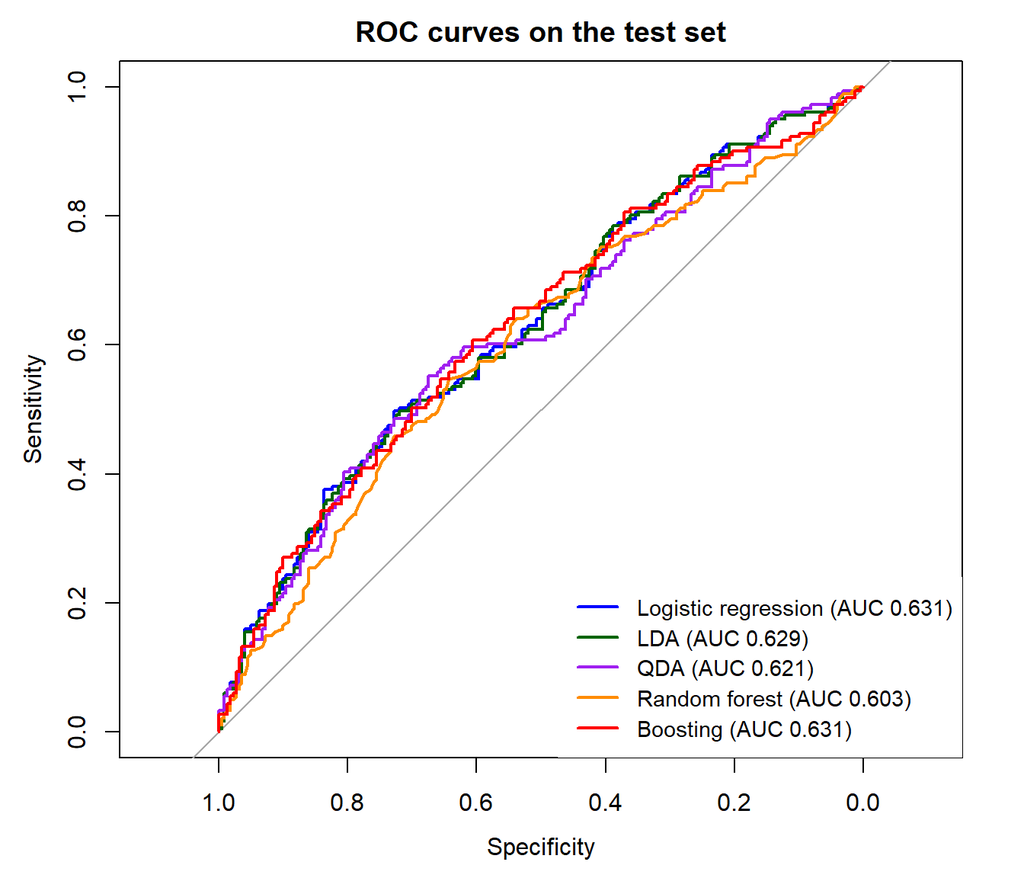

```r
roc_of <- function(prob) roc(df_test$rising, prob, levels = c(0, 1), direction = "<", quiet = TRUE)

roc_list <- list("Logistic regression" = roc_of(pred_prob),
                 "LDA"                 = roc_of(prob_lda),
                 "QDA"                 = roc_of(prob_qda),
                 "Random forest"       = roc_of(prob_rf),
                 "Boosting"            = roc_of(prob_boost))
roc_cols <- c("blue", "darkgreen", "purple", "darkorange", "red")

plot(roc_list[[1]], col = roc_cols[1], main = "ROC curves on the test set")
for (i in 2:length(roc_list)) plot(roc_list[[i]], col = roc_cols[i], add = TRUE)
legend("bottomright",
       legend = paste0(names(roc_list), " (AUC ", round(sapply(roc_list, auc), 3), ")"),
       col = roc_cols, lwd = 2, box.lty = 0, cex = 0.9)
```

The five curves lie on top of each other, a little above the diagonal, with AUCs between 0.60 and 0.63. A different threshold would not rescue any of them: there is no part of the curve where one model pulls away.

## 6.3 Where the models are right and wrong

Accuracy over six years hides which years. The logistic regression and the random forest, year by year, beside the share of districts that actually rose:

```r
df_test %>%
  mutate(logistic = as.integer(pred_prob > 0.5) == rising,
         forest   = as.integer(pred_rf_class == "Rise") == rising,
         predicted_rise = pred_prob > 0.5) %>%
  group_by(year) %>%
  summarise(districts = n(),
            share_rising = mean(rising),
            logistic_predicted_rising = mean(predicted_rise),
            logistic_accuracy = mean(logistic),
            forest_accuracy = mean(forest)) %>%
  mutate(across(-c(year, districts), ~ round(.x, 3))) %>%
  knitr::kable(caption = "Test accuracy by year (the class is the following year against this one)")
```

Test accuracy by year (the class is the following year against this one)

| year | districts | share_rising | logistic_predicted_rising | logistic_accuracy | forest_accuracy |
| --- | --- | --- | --- | --- | --- |
| 2019 | 67 | 0.448 | 0.582 | 0.567 | 0.552 |
| 2020 | 67 | 0.866 | 0.507 | 0.552 | 0.552 |
| 2021 | 67 | 0.373 | 0.418 | 0.627 | 0.582 |
| 2022 | 67 | 0.179 | 0.328 | 0.701 | 0.567 |
| 2023 | 67 | 0.224 | 0.075 | 0.761 | 0.597 |
| 2024 | 67 | 0.612 | 0.149 | 0.478 | 0.672 |

The logistic regression’s best years are 2022 and 2023 (70% and 76%): it predicted a fall for most districts and most districts fell. Its worst is 2024 (48%): it predicted a rise for 15% of districts and 61% rose. In 2020 it split the districts evenly when 87% were about to rise. The model does well while a downturn it can see in each district’s own numbers is still running, and badly at the turning points, which arrive for the whole country at once and for reasons that are not in a district’s consent record.

And by the size of the district, in three equal groups from the fewest dwellings a year to the most:

```r
df_test %>%
  mutate(size = cut(log_dwell, breaks = quantile(log_dwell, c(0, 1/3, 2/3, 1)),
                    labels = c("smallest third", "middle third", "largest third"),
                    include.lowest = TRUE),
         logistic = as.integer(pred_prob > 0.5) == rising,
         forest   = as.integer(pred_rf_class == "Rise") == rising,
         rule     = rule_reversion == rising) %>%
  group_by(size) %>%
  summarise(district_years = n(),
            median_dwellings = median(dwellings),
            rule_of_thumb_accuracy = mean(rule),
            logistic_accuracy = mean(logistic),
            forest_accuracy = mean(forest)) %>%
  mutate(across(c(rule_of_thumb_accuracy, logistic_accuracy, forest_accuracy), ~ round(.x, 3))) %>%
  knitr::kable(caption = "Test accuracy by district size")
```

Test accuracy by district size

| size | district_years | median_dwellings | rule_of_thumb_accuracy | logistic_accuracy | forest_accuracy |
| --- | --- | --- | --- | --- | --- |
| smallest third | 134 | 44 | 0.582 | 0.649 | 0.634 |
| middle third | 134 | 197 | 0.619 | 0.604 | 0.500 |
| largest third | 134 | 572 | 0.552 | 0.590 | 0.627 |

The logistic regression is most accurate in the smallest districts (65%) and least in the largest (59%). That is the wrong way round for usefulness: in a district that consents a few dozen dwellings a year, the change from one year to the next is mostly chance, chance does not repeat, and so a model built on mean reversion looks clever. Where the numbers are large enough for a change to mean something, the model has less to offer. The forest’s figures jump about from one third to the next; each third is 134 rows, so its accuracy has a standard error of about four points.

## 6.4 Is the test period typical?

Six test years are six draws of the national cycle, and section 2.1 showed they were unusual ones. The training years can be used to ask how the same models would have done in other periods: fit on four of the five blocks of years used for boosting, score on the fifth, and repeat. Each block is a set of years the model has not seen, so each score is an estimate of forecasting accuracy in a different era.

```r
# fit on four blocks of training years, score on the fifth
block_cv <- map_dfr(1:5, function(k) {
  train_k <- df_train[fold_id != k, ]
  valid_k <- df_train[fold_id == k, ]
  acc <- function(pred_class) mean(pred_class == valid_k$rising)

  fit_log <- glm(formula(logreg.fit), data = train_k, family = binomial)
  fit_lda <- lda(direction ~ ., data = train_da[fold_id != k, ])
  fit_qda <- qda(direction ~ ., data = train_da[fold_id != k, ])
  set.seed(462)
  fit_rf  <- randomForest(direction ~ ., data = train_tree[fold_id != k, ], mtry = 3, ntree = 500)

  tibble(years = paste(min(valid_k$year), max(valid_k$year), sep = "-"),
         rows = nrow(valid_k),
         share_rising = mean(valid_k$rising),
         rule_opposite = acc(as.integer(valid_k$g1 <= 0)),
         rule_3yr_average = acc(as.integer(valid_k$dev3 < 0)),
         logistic = acc(as.integer(predict(fit_log, newdata = valid_k, type = "response") > 0.5)),
         LDA = acc(as.integer(predict(fit_lda, newdata = train_da[fold_id == k, ])$class == "Rise")),
         QDA = acc(as.integer(predict(fit_qda, newdata = train_da[fold_id == k, ])$class == "Rise")),
         forest = acc(as.integer(predict(fit_rf, newdata = train_tree[fold_id == k, ]) == "Rise")))
})

# the five blocks pooled (weighted by rows), and the test set beside them
pooled <- block_cv %>%
  summarise(years = "1995-2018 pooled", across(-c(years, rows), ~ weighted.mean(.x, rows)),
            rows = sum(rows))

test_row <- tibble(years = "2019-2024 (test set)", rows = nrow(df_test),
                   share_rising = mean(df_test$rising),
                   rule_opposite = mean(rule_opposite == df_test$rising),
                   rule_3yr_average = mean(rule_reversion == df_test$rising),
                   logistic = mean(as.integer(pred_prob > 0.5) == df_test$rising),
                   LDA = mean(as.integer(prob_lda > 0.5) == df_test$rising),
                   QDA = mean(as.integer(prob_qda > 0.5) == df_test$rising),
                   forest = mean(as.integer(pred_rf_class == "Rise") == df_test$rising))

bind_rows(block_cv, pooled, test_row) %>%
  mutate(across(-c(years, rows), ~ round(.x, 3))) %>%
  knitr::kable(caption = "Accuracy on blocks of years the model was not fitted on, and on the test set")
```

Accuracy on blocks of years the model was not fitted on, and on the test set

| years | rows | share_rising | rule_opposite | rule_3yr_average | logistic | LDA | QDA | forest |
| --- | --- | --- | --- | --- | --- | --- | --- | --- |
| 1995-1999 | 334 | 0.476 | 0.605 | 0.545 | 0.479 | 0.470 | 0.488 | 0.488 |
| 2000-2004 | 335 | 0.669 | 0.445 | 0.499 | 0.660 | 0.663 | 0.579 | 0.588 |
| 2005-2009 | 335 | 0.400 | 0.513 | 0.513 | 0.469 | 0.460 | 0.475 | 0.534 |
| 2010-2014 | 335 | 0.507 | 0.540 | 0.519 | 0.570 | 0.570 | 0.582 | 0.576 |
| 2015-2018 | 268 | 0.631 | 0.466 | 0.481 | 0.567 | 0.571 | 0.571 | 0.586 |
| 1995-2018 pooled | 1607 | 0.533 | 0.516 | 0.513 | 0.548 | 0.546 | 0.538 | 0.553 |
| 2019-2024 (test set) | 402 | 0.450 | 0.540 | 0.585 | 0.614 | 0.612 | 0.590 | 0.587 |

```r
# the same check for the logistic regression without nat_g1
cv_without <- sapply(1:5, function(k) {
  fit <- glm(update(formula(logreg.fit), . ~ . - nat_g1), data = df_train[fold_id != k, ], family = binomial)
  sum(as.integer(predict(fit, newdata = df_train[fold_id == k, ], type = "response") > 0.5) ==
        df_train$rising[fold_id == k])
})
cat("Logistic regression without nat_g1, five blocks pooled:",
    round(sum(cv_without) / nrow(df_train), 3), "\n")
```

```
## Logistic regression without nat_g1, five blocks pooled: 0.572
```

On earlier years the picture is weaker than on the test set, for the rules and for every model.

- The mean-reversion rule that scored 58.5% on the test years scores 51.3% over 1995–2018, and is below 50% in two of the five blocks. Its test score was a feature of those six years — a boom followed by a bust is exactly when “what went up will come down” works — and not a property of the rule.
- Logistic regression averages 54.8% (LDA 54.6%, QDA 53.8%, the forest 55.3%) and ranges from 47% to 66% by block. In two of the five eras it would have done worse than a coin.
- The gain from modelling over the pencil rule is about the same in both places, three to four points. What changes between the test years and the earlier ones is the level, for everything.

So the honest statement of how well a district’s consent record forecasts its direction is not 61%. It is about 55% on average, and anywhere from 47% to 66% depending on the period, with the test years at the favourable end.

The second chunk is about `nat_g1`. Over the five blocks the logistic regression is right 57.2% of the time *without* it and 54.8% with it; on the test set it is the other way round, by a point and a half (next section). A feature with 24 distinct values in training is easy to overfit, and this is what that looks like: it helps in some periods and hurts in others. It stays in the headline model, as decided before the results were seen, but it should not be described as a predictor that works.

## 6.5 Sensitivity checks

Three things we decided could have gone another way. Each is re-run with logistic regression, LDA and a random forest (on the features alone, no `region`, so that the rows are comparable).

```r
# refit three of the models on a different set of rows or features and score them on its test rows
refit <- function(label, train, test, feats) {
  rhs <- paste(feats, collapse = " + ")

  fit_log  <- glm(as.formula(paste("rising ~", rhs)), data = train, family = binomial)
  prob_log <- predict(fit_log, newdata = test, type = "response")

  fit_lda  <- lda(as.formula(paste("direction ~", rhs)), data = train)
  prob_lda <- predict(fit_lda, newdata = test)$posterior[, "Rise"]

  set.seed(462)
  fit_rf  <- randomForest(as.formula(paste("direction ~", rhs)), data = train, mtry = 3, ntree = 500)
  prob_rf <- predict(fit_rf, newdata = test, type = "prob")[, "Rise"]

  acc <- function(prob) mean(as.integer(prob > 0.5) == test$rising)
  auc_here <- function(prob) as.numeric(auc(roc(test$rising, prob, levels = c(0, 1),
                                                direction = "<", quiet = TRUE)))

  tibble(run = label, train_rows = nrow(train), test_rows = nrow(test),
         test_share_rising = mean(test$rising),
         best_rule = mean(as.integer(test$dev3 < 0) == test$rising),
         logistic = acc(prob_log), logistic_AUC = auc_here(prob_log),
         LDA = acc(prob_lda), forest = acc(prob_rf), forest_AUC = auc_here(prob_rf))
}

big_move <- function(d) d %>% dplyr::filter(abs(change) >= log(1.10))

sensitivity <- bind_rows(
  refit("Headline: 9 features, all rows", df_train, df_test, features),
  refit("Without nat_g1", df_train, df_test, setdiff(features, "nat_g1")),
  refit("With relative cost per m2 added", drop_na(df_train, rel_cost), drop_na(df_test, rel_cost),
        c(features, "rel_cost")),
  refit("Moves of more than 10% only", big_move(df_train), big_move(df_test), features)
)

sensitivity %>%
  mutate(across(-c(run, train_rows, test_rows), ~ round(.x, 3))) %>%
  knitr::kable(caption = "Sensitivity checks: test accuracy (and AUC) under three alternative choices")
```

Sensitivity checks: test accuracy (and AUC) under three alternative choices

| run | train_rows | test_rows | test_share_rising | best_rule | logistic | logistic_AUC | LDA | forest | forest_AUC |
| --- | --- | --- | --- | --- | --- | --- | --- | --- | --- |
| Headline: 9 features, all rows | 1607 | 402 | 0.450 | 0.585 | 0.614 | 0.631 | 0.612 | 0.597 | 0.607 |
| Without nat_g1 | 1607 | 402 | 0.450 | 0.585 | 0.600 | 0.624 | 0.597 | 0.577 | 0.598 |
| With relative cost per m2 added | 1600 | 401 | 0.451 | 0.586 | 0.599 | 0.625 | 0.599 | 0.591 | 0.599 |
| Moves of more than 10% only | 1192 | 296 | 0.466 | 0.595 | 0.652 | 0.693 | 0.642 | 0.622 | 0.675 |

```r
# how small the typical move is
cat("Median size of next year's move, as a log change:", round(median(abs(df$change)), 3), "\n")
```

```
## Median size of next year's move, as a log change: 0.192
```

```r
cat("Share of district-years that moved less than 10% either way:",
    round(mean(abs(df$change) < log(1.10)), 3), "\n")
```

```
## Share of district-years that moved less than 10% either way: 0.259
```

- **Without `nat_g1`.** Test accuracy falls by a point or two for all three models (logistic regression 60.0% from 61.4%). Section 6.4 found the opposite on earlier years. Either way the feature moves the result by less than the noise in a 402-row test set.
- **With cost per m² added.** No gain: 59.9% for both logistic regression and LDA. What a district’s houses cost relative to the rest of the country says nothing about which way its consents will move, which keeps this question cleanly apart from RQ1.
- **Large moves only.** Dropping the district-years that moved by less than 10% either way — 26% of all rows — lifts logistic regression to 65.2% and its AUC to 0.69. So part of the difficulty is the class itself: a quarter of district-years barely move, and whether a 3% change counts as a rise or a fall is close to chance. But only part: with the small moves gone, the models are still wrong one time in three.

## 6.6 Which features matter

Three rankings side by side: the size of each logistic coefficient per standard deviation, the random forest’s mean decrease in accuracy when the feature is shuffled, and boosting’s relative influence.

```r
rf_imp  <- importance(rf.tree)[, "MeanDecreaseAccuracy"]
gbm_inf <- summary(boost.fit, plotit = FALSE)
gbm_inf <- setNames(gbm_inf$rel.inf, as.character(gbm_inf$var))

tibble(feature = c(features, "region")) %>%
  mutate(logistic_per_sd = c(std_coef[features], NA),
         forest_accuracy_drop = rf_imp[feature],
         boosting_influence = gbm_inf[feature],
         rank_logistic = rank(-abs(logistic_per_sd), na.last = "keep"),
         rank_forest   = rank(-forest_accuracy_drop),
         rank_boosting = rank(-boosting_influence)) %>%
  arrange(rank_forest) %>%
  mutate(across(c(logistic_per_sd, forest_accuracy_drop, boosting_influence), ~ round(.x, 2))) %>%
  knitr::kable(caption = "Feature importance: three models, three measures")
```

Feature importance: three models, three measures

| feature | logistic_per_sd | forest_accuracy_drop | boosting_influence | rank_logistic | rank_forest | rank_boosting |
| --- | --- | --- | --- | --- | --- | --- |
| nat_g1 | 0.16 | 24.98 | 25.89 | 7 | 1 | 2 |
| h2_h1 | 0.28 | 10.69 | 26.39 | 4 | 2 | 1 |
| dev3 | 0.17 | 10.12 | 6.04 | 6 | 3 | 6 |
| alt_share | 0.36 | 8.16 | 9.28 | 1 | 4 | 4 |
| multi_share | -0.29 | 7.30 | 13.10 | 3 | 5 | 3 |
| g1 | -0.30 | 7.12 | 8.57 | 2 | 6 | 5 |
| log_dwell | 0.27 | 6.13 | 0.53 | 5 | 7 | 9 |
| nonres_share | 0.08 | 5.20 | 4.53 | 8 | 8 | 8 |
| cv5 | -0.04 | 1.35 | 0.18 | 9 | 9 | 10 |
| region | NA | -2.01 | 5.50 | NA | 10 | 7 |

The three measures do not agree on an order, which is itself a sign that no feature is doing much. They do agree on a short list. `h2_h1` — did the year finish stronger than it started — is in the top four of all three and first for boosting. `alt_share` is first for the logistic regression and fourth for both ensembles. `nat_g1` is first or second for the two ensembles and seventh for the logistic regression: a tree can use it as a label for particular years, splitting on single values, where a linear model can only use its slope — which is also how it gets overfitted. `cv5` and `nonres_share` are at or near the bottom of every list.

`region` is last in the forest, where shuffling it makes the forest no worse, and seventh for boosting. In RQ1 location was the largest single part of the answer. Here it is none of it: where a district is says a great deal about what building costs there, and nothing about which way its consents will move next year.

## 6.7 Where this leaves RQ3

The answer has three parts, each pointing at the table or figure behind it.

Only slightly. On the outcomes of 2020 to 2025 the best models call the direction of a district’s consents correctly 61% of the time (logistic regression and LDA, section 6.1), against 45% for always guessing the more common class and 58.5% for a rule that needs one subtraction. On five earlier blocks of years the same models average 55% and the rule 51% (section 6.4). The fair summary is that a district’s own consent record beats a coin toss by about five points in an ordinary period and about ten in a boom-and-bust like 2019–2024, and that no model beats the best pencil rule by more than three or four.

The reason is the national cycle. Two-thirds of district-years move the way most of the country moves (section 2.1), and nothing in a single district’s record says which way that will be: the models are right in the years when a downturn already under way continues, and wrong at the turning points (section 6.3). What the models do learn is modest and makes sense — a district that grew this year is a little less likely to grow again, one that finished the year strongly is a little more likely to, and one doing relatively more work on existing homes has room to recover (section 3.2) — and it works best in the smallest districts, where the change from year to year is mostly chance (section 6.3).

The method matters least, which is the conclusion of RQ1 again from a different kind of problem. Logistic regression, LDA, QDA, a random forest and boosting are within three points of each other on the test set, with AUCs between 0.60 and 0.63 (section 6.2), and LDA and logistic regression make the same call on 395 of 402 test rows. Location, which carried most of RQ1, carries nothing here (section 6.6).

For the poster, the defensible line is: *next year’s direction is mostly the national cycle; a district’s own record adds a little, and the choice of model adds almost nothing.* Any accuracy quoted should be the pair — 61% on the test years, 55% on earlier years — and not the 61% alone. Niwesh’s independent build reported 58% for this question at the 9 November meeting, inside the same band.

**Limitations.** The test set is six years, which is six draws of the national cycle, not 402 independent cases. The class treats a 1% change and a 50% change alike, and counts 52 exact ties as falls. Every feature comes from the consents data; the things that turn the national cycle — interest rates, migration, construction costs — are not in it, and with one value a year they would give a model about 24 points to learn from. `cv.tree()` and the forests’ out-of-bag error use random folds, which flatter a model when districts move together. Consents record intentions to build, not completed buildings.

**Sources.** Stats NZ, *Building consents issued: August 2026* (CC BY 4.0), via the district-quarter table built in Niwesh’s Step 1 notebook. Methods and code patterns follow STAT462 Lab Modules 3 (logistic regression), 4 (discriminant analysis), 5 (cross-validation) and 6 (tree-based methods).

*End of document*